# time series use R

时间序列分析在数据分析中发挥着预测和分析的作用。

R中时间序列分析的基础package是ts。

```r
# 首先建立一个模拟的向量可以表示真实世界的时间序列数据过程。比如从1到100，但具有随机噪音
set.seed(123)
t <- seq(from = 1, to = 100, by = 1) + 10 + rnorm(100, sd = 7)
plot(t)
# 使用args函数看函数的参数设置
args(ts)
function (data = NA, start = 1, end = numeric(), frequency = 1,
    deltat = 1, ts.eps = getOption("ts.eps"), class = if (nseries >
        1) c("mts", "ts", "matrix") else "ts", names = if (!is.null(dimnames(data))) colnames(data) else paste("Series",
        seq(nseries)))
NULL
```

首先参数中data代表时间序列数据，一个向量或者矩阵，start和end代表时间的范围。最后的频率可以指定时间的单位。例如，如果我们使用月数据，可以设置12代表频率。 本案例中设置季度为频率，所以为4。

```r
tseries <- ts(t, start = c(2000, 1), frequency = 4)
print(tseries)
plot(tseries)
```

在这种情况下，数据被识别为ts序列，如果ts参数中的data是一个矩阵，那么图中会产生多条时间序列线。

```r
set.seed(123)
seq <- seq(from = 1, to = 100, by = 1) + 10
ts1 <- seq + rnorm(100, sd = 5)
ts2 <- seq + rnorm(100, sd = 12)
ts3 <- seq^2 + rnorm(100, sd = 300)
tsm <- cbind(ts1, ts2, ts3)
tsm <- ts(tsm, start=c(2000, 1), frequency = 4)
plot(tsm)
plot.ts(tsm)
```

plot 和plot.ts是一样的，在本案例中，序列自动被识别。

```r
args(plot.ts)
```

```
function (x, y = NULL, plot.type = c("multiple", "single"), xy.labels,
    xy.lines, panel = lines, nc, yax.flip = FALSE, mar.multi = c(0,
        5.1, 0, if (yax.flip) 5.1 else 2.1), oma.multi = c(6,
        0, 5, 0), axes = TRUE, ...)
NULL
```

在plot.ts中，参数设置不同于plot 另外，还有一些函数用于数据的提取，比如window()用于提取指定时间范围内的数据。start用于看时间起点，end是终点，frequency是频率，本案例中为4。

```r
tseries_sub <- window(tseries, start=c(2000, 1), end=c(2012,4))
print(tseries_sub)

start(tsm)
end(tsm)
frequency(tsm)
```

如何处理时间序列数据

```r
tseries_lag1 <- lag(tseries, 1)
head(cbind(tseries, tseries_lag1))
tseries_lag1 <- lag(tseries, 3)
```

lag函数用于对序列进行向前进位的处理，比如向前进1位或者3位。 diff函数用于提取时间序列的差分

```r
tseries_diff1 <- diff(tseries, lag = 1) # lag设置差分的位数
tm <- cbind(tseries, tseries_diff1)
head(tm)
plot.ts(tm)
```

或者差分2位，diff函数有效的去除了趋势成分，保留静态的噪声成分。

```r
tseries_diff2 <- diff(tseries, lag = 2)
tm <- cbind(tseries, tseries_diff2)
head(tm)
plot.ts(tm)
```

有时候时间序列数据的方差会越来越大

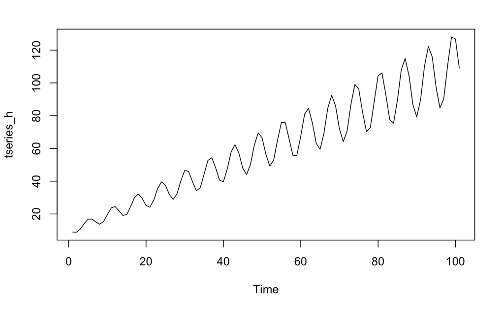

```r
trend <- ts(seq(from = 10, to = 110))
cycle <- ts(sin(trend)) * 0.2 * trend
tseries_h <- trend + cycle
plot.ts(tseries_h)
```

方差越来越大会导致heteroskedasticity，违背了线性回归的基本假设，所以通过log方法对数据进行转化

```r
tseries_log <- log(tseries_h)
tm <-cbind(tseries_h, tseries_log)
plot.ts(tm)
```

另一种去除非恒定方差的方法是box-cox转化。

```r
library("forecast")
plot.ts(BoxCox(tseries_h, lambda = 0.5))
```

box-cox变换中lambda的值并不能完全去除掉heteroskedasticity问题，我们可以设定不同的lambda值，以寻找到最合适的

```r
lambda <- BoxCox.lambda(tseries_h)
print(lambda)
plot.ts(BoxCox(tseries_h, lambda = lambda))
```

对于时间序列，另一个常见的计算方法是看一个时间的数据相对于前一个时间数据变化的程度。

```r
tseries_pch <- tseries / lag(tseries, -1) - 1
head(cbind(tseries, tseries_pch))
# 根据上面写一个函数
pch <- function(data, lag = 1) {
    # argument verification
    if (!is.ts(data)) stop("data must be of type ts") # 判别函数
    if (!is.numeric(lag)) stop("lag must be of type numeric") # 判别lag函数
    # return percent change
    data / lag(data, -lag) - 1
}
head(cbind(tseries, pch(tseries)))
```

有了这个函数，我们可以看每年同时期的数据变化，所以设置lag=4

```r
tseries_pchya <- pch(tseries, lag=4)
tseries_dlog <- ts(diff(log(tseries)), start = c(2000, 1), frequency = 4)
plot.ts(cbind(tseries, tseries_dlog))
plot.ts(cbind(pch(tseries), tseries_dlog))
```

时间序列另一个方案，移动平均moving average，对于具有高变化性的数据，移动平均可以看出数据的趋势

```r
tseries_lf5 <- filter(tseries, filter = rep(1/5, 5), sides = 1)
plot.ts(cbind(tseries, tseries_lf5), plot.type = 'single', col = c('black', 'red'))
```

或者使用一个SMA函数

[figure not shown]